# Quant: Final Assignment

#### **9. Age**

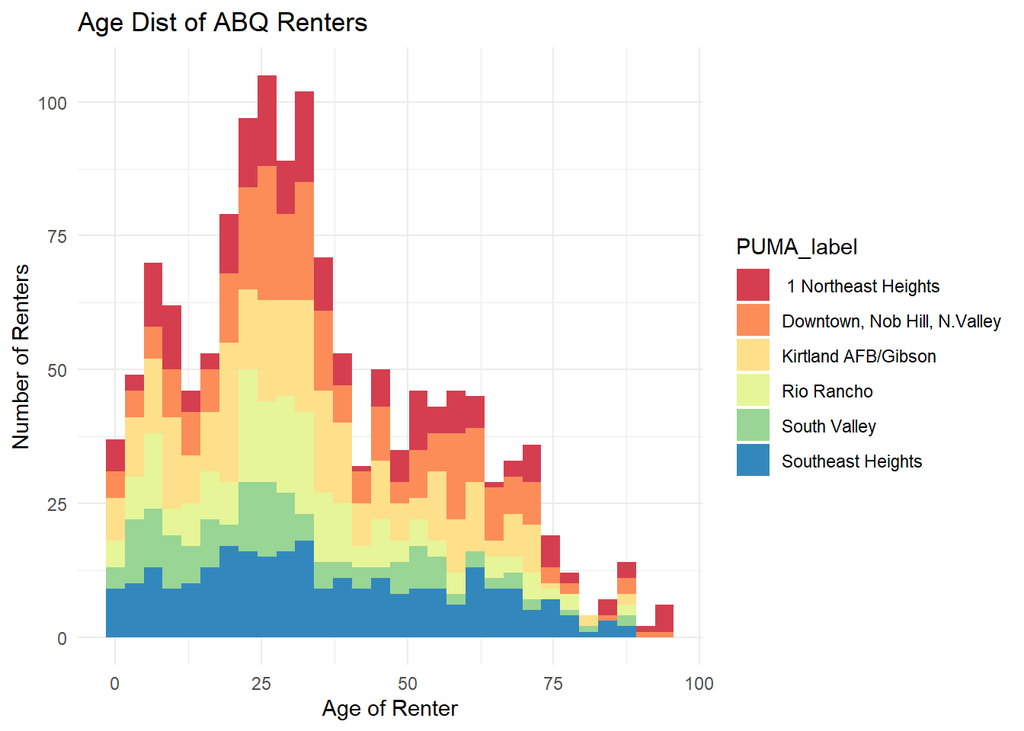

```r
AGEP_hist <- ggplot(ass6_ABQs_renters, aes(AGEP)) +
  scale_fill_brewer(palette = "Spectral") +
  geom_histogram(aes(fill= PUMA_label, breaks =100)) +
  labs(title="Age Dist of ABQ Renters")  +
  scale_y_continuous(name="Number of Renters") +
  scale_x_continuous(name="Age of Renter") +
  theme_minimal()
  AGEP_hist
```

```r
  summary(ass6_ABQs_renters$AGEP)
```

```
##    Min. 1st Qu.  Median    Mean 3rd Qu.    Max.
##    0.00   19.00   30.00   34.37   50.00   94.00
```

#### **10. Rent**

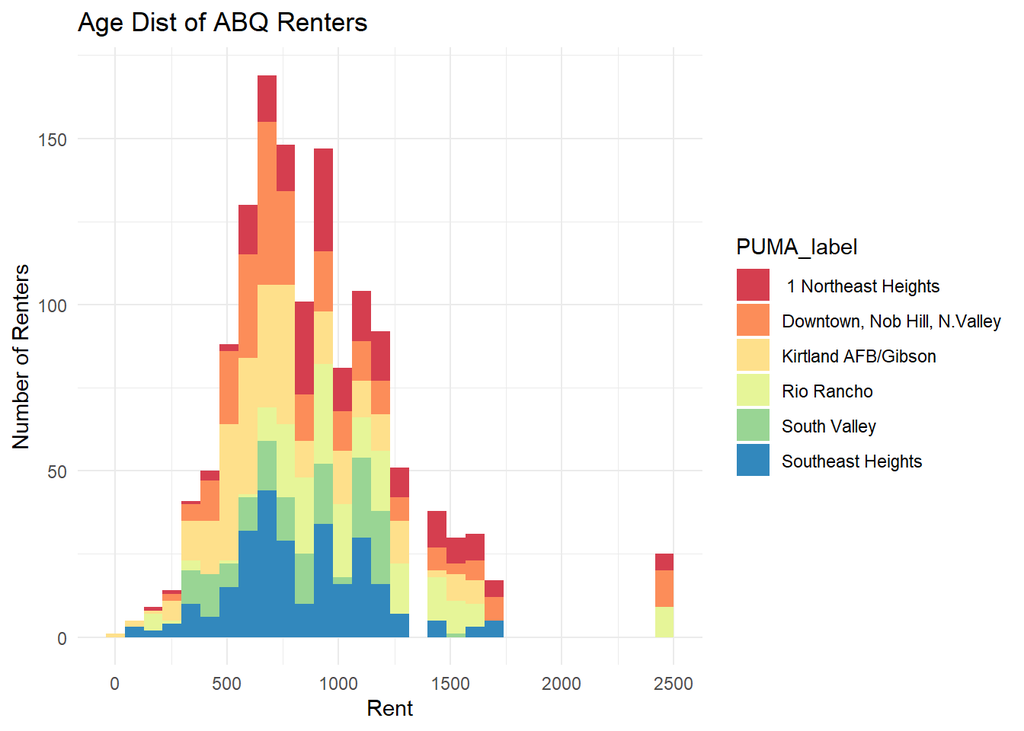

```r
RENT_hist <- ggplot(ass6_ABQs_renters, aes(RNTP)) +
  scale_fill_brewer(palette = "Spectral") +
  geom_histogram(aes(fill= PUMA_label)) +
  labs(title="Age Dist of ABQ Renters")  +
  scale_y_continuous(name="Number of Renters") +
  scale_x_continuous(name="Rent") +
  theme_minimal()
  RENT_hist
```

ABQ Rent Summary Stats:

```r
  summary(ass6_ABQs_renters$RNTP)
```

```
##    Min. 1st Qu.  Median    Mean 3rd Qu.    Max.
##      40     640     830     894    1100    2500
```

Northeast Heights Summary Stats:

```r
  summary(ass6_NEHeights_renters$RNTP)
```

```
##    Min. 1st Qu.  Median    Mean 3rd Qu.    Max.
##     170     800     950    1030    1200    2500
```

Southeast Heights Summary Stats:

```r
  summary(ass6_SEHeights_renters$RNTP)
```

```
##    Min. 1st Qu.  Median    Mean 3rd Qu.    Max.
##    90.0   630.0   780.0   825.4  1000.0  1700.0
```

KAFB/Gibson Summary Stats:

```r
  summary(ass6_KAFB_renters$RNTP)
```

```
##    Min. 1st Qu.  Median    Mean 3rd Qu.    Max.
##    40.0   550.0   700.0   762.8   950.0  1600.0
```

Downtown/Nob Hill/North Valley Summary Stats:

```r
  summary(ass6_DT_NH_NV_renters$RNTP)
```

```
##    Min. 1st Qu.  Median    Mean 3rd Qu.    Max.
##   220.0   620.0   750.0   901.7  1000.0  2500.0
```

South Valley Summary Stats:

```r
  summary(ass6_SVALLEY_renters$RNTP)
```

[output not shown]

Rio Rancho Summary Stats:

```r
  summary(ass6_RIO_R_renters$RNTP)
```

```
##    Min. 1st Qu.  Median    Mean 3rd Qu.    Max.
##     160     840    1000    1077    1300    2500
```

## **Results: Part 1**

**Relationships Between Rent Burden & Other Variables in DataSet**

For the first part of the analysis, I ran two types of relationships. First, for cases where I was comparing Rent Burden to a continuous variable, I used a Pearson’s correlation which outputs both a correlation and whether or not the relationship is statistically significant. Second, for Rent Burden and categorical variables, I ran ANOVA tests which output whether or not the relationship is statistically significant. For both tests I am looking for a p-value of less than 0.05 to indicate statistic significance.

Following these calculations, I visualized several relationships that were of interest.

### **Pearson’s Correlations**

```r
##Household Income
cor_GRPIP_HINCP <- cor.test(ass6_ABQs_renters$GRPIP, ass6_ABQs_renters$HINCP)

##Personal Income
cor_GRPIP_PINCP <- cor.test(ass6_ABQs_renters$GRPIP, ass6_ABQs_renters$PINCP)

###Income Per Person
cor_GRPIP_ipp <- cor.test(ass6_ABQs_renters$GRPIP, ass6_ABQs_renters$income_per_person)

##AGEP
cor_GRPIP_AGEP  <- cor.test(ass6_ABQs_renters$GRPIP, ass6_ABQs_renters$AGEP)

##RENT
cor_GRPIP_RNTP  <- cor.test(ass6_ABQs_renters$GRPIP, ass6_ABQs_renters$RNTP)



df_pcor_abq <- data.frame(
  'variable' = c("Household Income", "Personal Income", "Income Per Person", "Age", "Rent"),
 'correlation' = c(-0.5469677  , -0.3357144, -0.4577715, -0.4098563 , -0.06435763),
 'Pvalue' = c(2.2e-16, 2.2e-16, 2.2e-16, 0.05237627, 0.01712),
  stringsAsFactors = FALSE)


formattable(df_pcor_abq, list( 'Pvalue' = formatter("span", style = x ~ ifelse(x <= .05, style(color = "green", font.weight = "bold"), NA))))
```

[output not shown]

Here I can see that the results of the Pearson’s show that Income and Rent both have a statistically significant relationship with Rent Burden while age does not. For income we see an inverse correlation that shows as income increases, rent burden decreases. This relationship is closer to one (ie closer to perfectly correlated) when we look at Household Income and less correlated when we look at Personal Income. Rent Burden & Household Income per Person’s correlation falls between the two other correlations for income.

Given that Household Income per Person does a better job at capturing unpaid labor, it is the variable that I will be using going forward in this analysis.

### **Anova Tests**

```r
## ANOVA TESTS
abq_renters_aov <- aov(GRPIP ~ PUMA_label + race_ethn + SCHL_simp + NP_simp +bld_type + when_built + JWMNP_binned + bld_type, data = assignment6_vars)
summary(abq_renters_aov)
```

```
##                Df  Sum Sq Mean Sq F value   Pr(>F)
## PUMA_label      5   48832    9766  26.617  < 2e-16 ***
## race_ethn       6   28253    4709  12.833 1.97e-14 ***
## SCHL_simp       4   32144    8036  21.901  < 2e-16 ***
## NP_simp         2   25210   12605  34.353 1.54e-15 ***
## bld_type        3  550109  183370 499.745  < 2e-16 ***
## when_built      4   19814    4954  13.500 6.06e-11 ***
## JWMNP_binned    5    2431     486   1.325     0.25
## Residuals    4735 1737399     367
## ---
## Signif. codes:  0 '***' 0.001 '**' 0.01 '*' 0.05 '.' 0.1 ' ' 1
## 117 observations deleted due to missingness
```

The ANOVA test shows me that all of the variables are statistically significant with the exception of commute to work.

### **Visualizations of Selected Relationships**

#### **Rent Burden + Race & Ethnicity**

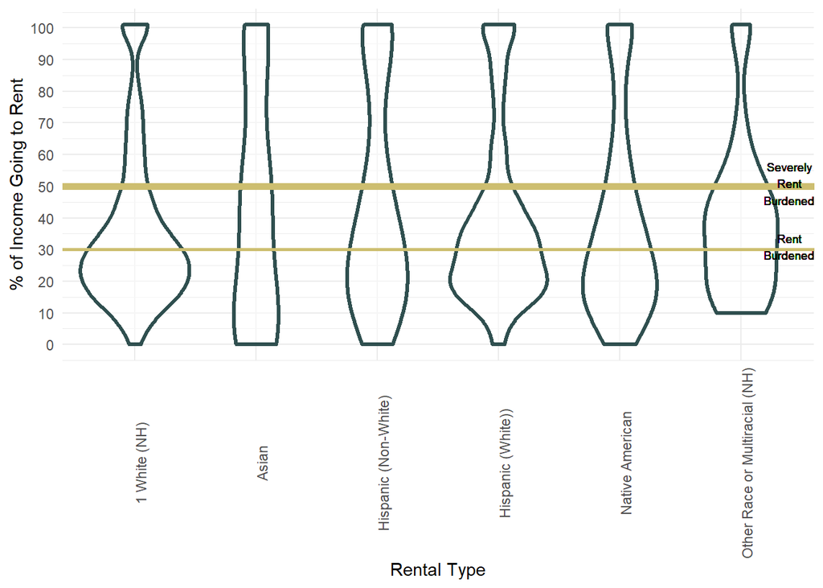

```r
ggplot(ass6_ABQs_renters, aes(x =race_ethn, y = GRPIP)) +
  geom_violin(color="darkslategray", size =1.2, alpha =.5) +
  theme_minimal() +
  scale_x_discrete(name = "Rental Type") +
  scale_y_continuous(name = "% of Income Going to Rent",
                     breaks = seq(0, 101, by = 10),
                     label = paste(prettyNum(seq(0, 101, by = 10))))  +
   theme(axis.text.x = element_text(angle = 90)) +
   geom_segment(
                y=30,
                yend=30,
                x=0,
                xend=100,
                alpha=.8,
                size=1,
                color ="lightgoldenrod3") +

geom_segment(y=50,
                yend=50,
                x=0,
                xend=100,
                alpha=.8,
                size =2,
                color ="lightgoldenrod3") +
  geom_text(aes(label=str_wrap("Rent Burdened",4),
                 y= 31,
                 x=6.4),
                 size=2.5,
                 color ="black") +

geom_text(aes(label=str_wrap("Severely Rent Burdened",4),
                 y= 51,
                 x=6.4),
                 size=2.5,
                 color ="black")
```

#### **Rent Burden & Rent**

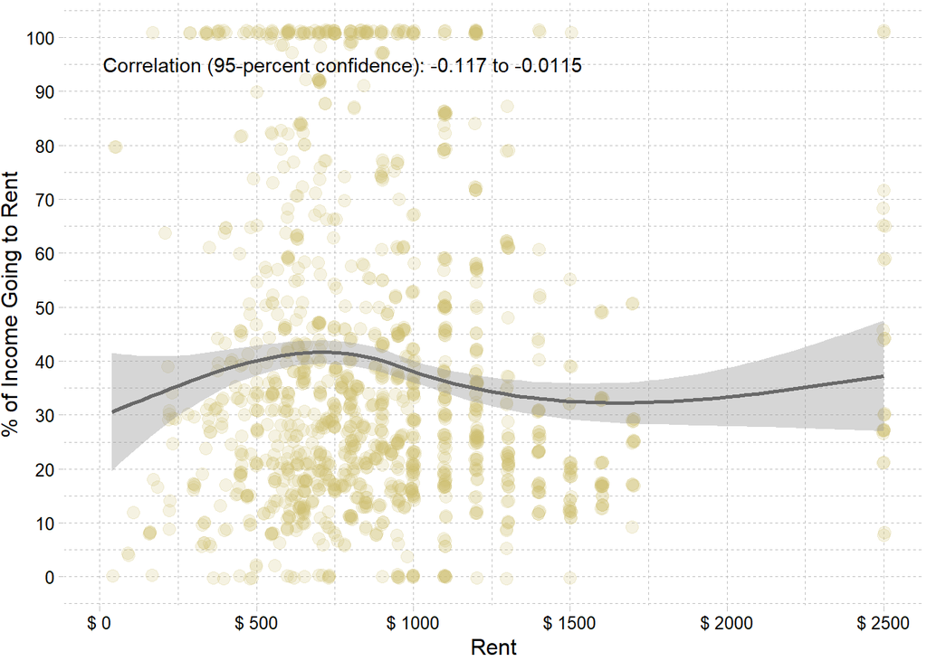

```r
##Thanks to Meghan Casey for this formatting scheme
ggplot(ass6_ABQs_renters, aes(x = RNTP, y = GRPIP)) +
  geom_point(size = 3, alpha = 0.2, position = "jitter", color = "lightgoldenrod3") +
  geom_smooth(color = "dimgray") +
  theme_pander() +
  scale_x_continuous(name = "Rent",
                     breaks = seq(0, 2500, by = 500),
                     label = paste("$", (prettyNum(seq(0, 2500, by = 500))))) +
  scale_y_continuous(name = "% of Income Going to Rent",
                     breaks = seq(0, 101, by = 10),
                     label = paste(prettyNum(seq(0, 101, by = 10)))) +

  annotate(geom = "text", x = 10, y = 95,
           label = paste("Correlation (95-percent confidence):",
                         prettyNum(cor_GRPIP_RNTP$conf.int[1], digits = 3),
                         "to",
                         prettyNum(cor_GRPIP_RNTP$conf.int[2], digits = 3)),
           hjust = 0)
```

#### **Rent Burden & Income Per Person**

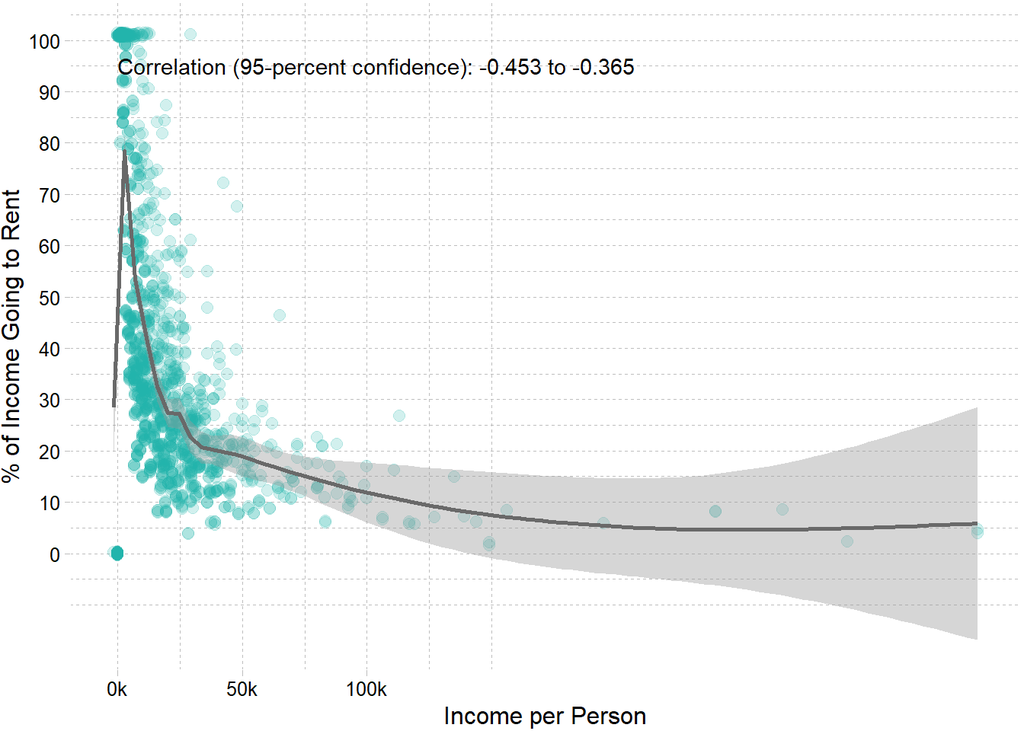

```r
ggplot(ass6_ABQs_renters, aes(x = income_per_person, y = GRPIP)) +
  geom_point(size = 2.5, alpha = 0.2, position = "jitter", color = "lightseagreen") +
  geom_smooth(color = "dimgray") +
  theme_pander() +
  scale_x_continuous(name = "Income per Person",
                     breaks = seq(0, 100000, by = 50000),
                     label = paste(seq(0, 100, by = 50),
                                           "k", sep = "")) +
  scale_y_continuous(name = "% of Income Going to Rent",
                     breaks = seq(0, 101, by = 10),
                     label = paste(prettyNum(seq(0, 101, by = 10)))) +

  annotate(geom = "text", x = 10, y = 95,
           label = paste("Correlation (95-percent confidence):",
                         prettyNum(cor_GRPIP_ipp$conf.int[1], digits = 3),
                         "to",
                         prettyNum(cor_GRPIP_ipp$conf.int[2], digits = 3)),
           hjust = 0)
```

#### **Rent Burden and Rental Type**

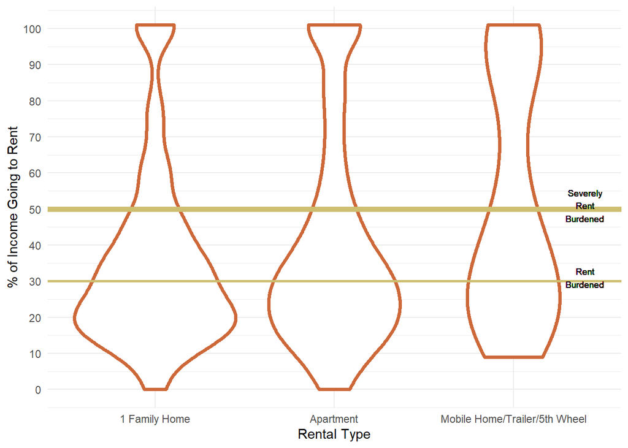

```r
ggplot(ass6_ABQs_renters, aes(x =bld_type, y = GRPIP)) +
  geom_violin(color="sienna3", size =1.4) +
  theme_minimal() +
  scale_x_discrete(name = "Rental Type") +
  scale_y_continuous(name = "% of Income Going to Rent",
                     breaks = seq(0, 101, by = 10),
                     label = paste(prettyNum(seq(0, 101, by = 10))))  +
   geom_segment(
                y=30,
                yend=30,
                x=0,
                xend=100,
                alpha=.8,
                size=1,
                color ="lightgoldenrod3") +

geom_segment(y=50,
                yend=50,
                x=0,
                xend=100,
                alpha=.8,
                size =2,
                color ="lightgoldenrod3") +
  geom_text(aes(label=str_wrap("Rent Burdened",4),
                 y= 31,
                 x=3.4),
                 size=2.5,
                 color ="black") +

geom_text(aes(label=str_wrap("Severely Rent Burdened",4),
                 y= 51,
                 x=3.4),
                 size=2.5,
                 color ="black")
```

#### **Rent Burden & Household Size**

##### **All Renters**

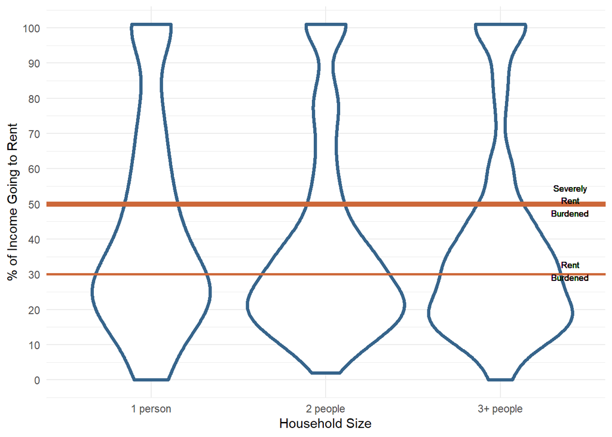

```r
ggplot(ass6_ABQs_renters, aes(x =NP_simp, y = GRPIP)) +
  geom_violin(color="steelblue4", size =1.4) +
  theme_minimal() +
  scale_x_discrete(name = "Household Size") +
  scale_y_continuous(name = "% of Income Going to Rent",
                     breaks = seq(0, 101, by = 10),
                     label = paste(prettyNum(seq(0, 101, by = 10))))  +
   geom_segment(
                y=30,
                yend=30,
                x=0,
                xend=100,
                alpha=.8,
                size=1,
                color ="sienna3") +

geom_segment(
                y=50,
                yend=50,
                x=0,
                xend=100,
                alpha=.8,
                size =2,
                color ="sienna3")+
  geom_text(aes(label=str_wrap("Rent Burdened",4),
                 y= 31,
                 x=3.4),
                 size=2.5,
                 color ="black") +

geom_text(aes(label=str_wrap("Severely Rent Burdened",4),
                 y= 51,
                 x=3.4),
                 size=2.5,
                 color ="black")
```

##### Northeast Heights

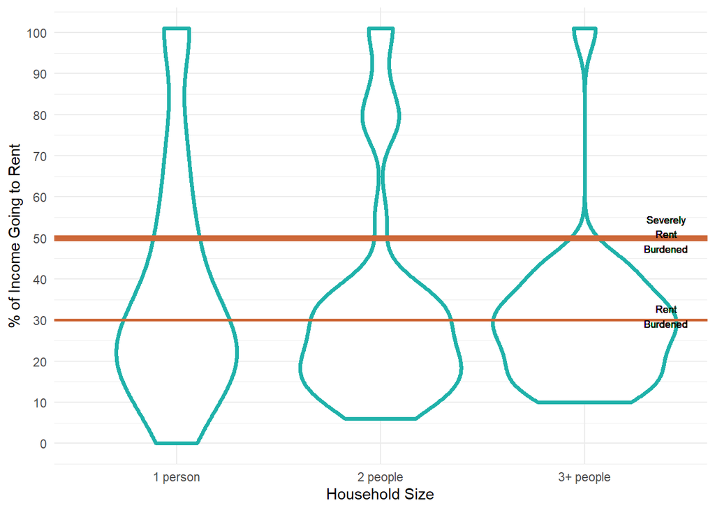

```r
ggplot(ass6_NEHeights_renters, aes(x =NP_simp, y = GRPIP)) +
  geom_violin(color="lightseagreen", size =1.4) +
  theme_minimal() +
  scale_x_discrete(name = "Household Size") +
  scale_y_continuous(name = "% of Income Going to Rent",
                     breaks = seq(0, 101, by = 10),
                     label = paste(prettyNum(seq(0, 101, by = 10))))  +
   geom_segment(
                y=30,
                yend=30,
                x=0,
                xend=100,
                alpha=.8,
                size=1,
                color ="sienna3") +

geom_segment(
                y=50,
                yend=50,
                x=0,
                xend=100,
                alpha=.8,
                size =2,
                color ="sienna3") +

  geom_text(aes(label=str_wrap("Rent Burdened",4),
                 y= 31,
                 x=3.4),
                 size=2.5,
                 color ="black") +

geom_text(aes(label=str_wrap("Severely Rent Burdened",4),
                 y= 51,
                 x=3.4),
                 size=2.5,
                 color ="black")
```

##### KAFB/GIbson

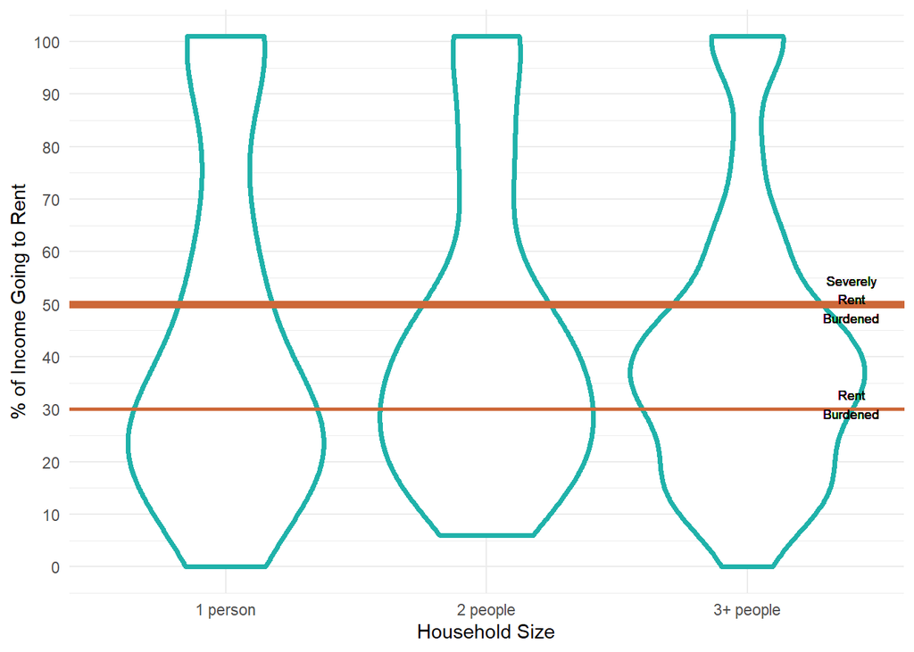

```r
ggplot(ass6_KAFB_renters, aes(x =NP_simp, y = GRPIP)) +
  geom_violin(color="lightseagreen", size =1.4) +
  theme_minimal() +
  scale_x_discrete(name = "Household Size") +
  scale_y_continuous(name = "% of Income Going to Rent",
                     breaks = seq(0, 101, by = 10),
                     label = paste(prettyNum(seq(0, 101, by = 10)))) +
   geom_segment(
                y=30,
                yend=30,
                x=0,
                xend=100,
                alpha=.8,
                size=1,
                color ="sienna3") +

geom_segment(
                y=50,
                yend=50,
                x=0,
                xend=100,
                alpha=.8,
                size =2,
                color ="sienna3") +

  geom_text(aes(label=str_wrap("Rent Burdened",4),
                 y= 31,
                 x=3.4),
                 size=2.5,
                 color ="black") +

geom_text(aes(label=str_wrap("Severely Rent Burdened",4),
                 y= 51,
                 x=3.4),
                 size=2.5,
                 color ="black")
```

##### South Valley

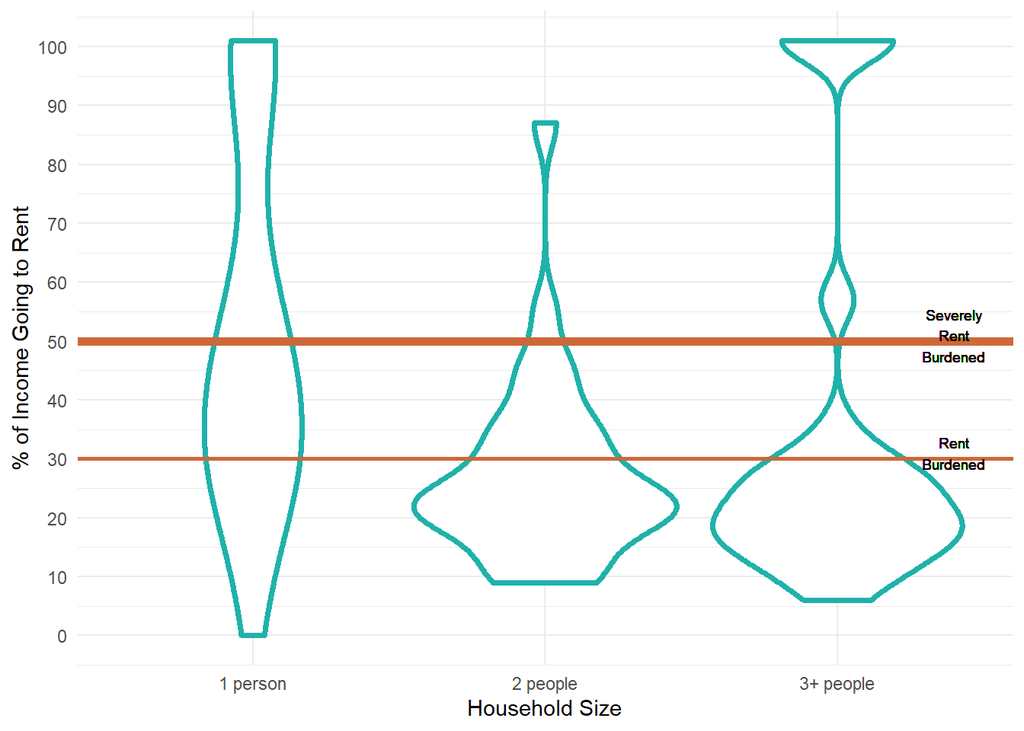

```r
ggplot(ass6_SVALLEY_renters, aes(x =NP_simp, y = GRPIP)) +
  geom_violin(color="lightseagreen", size =1.4) +
  theme_minimal() +
  scale_x_discrete(name = "Household Size") +
  scale_y_continuous(name = "% of Income Going to Rent",
                     breaks = seq(0, 101, by = 10),
                     label = paste(prettyNum(seq(0, 101, by = 10))))  +
   geom_segment(
                y=30,
                yend=30,
                x=0,
                xend=100,
                alpha=.8,
                size=1,
                color ="sienna3") +

geom_segment(
                y=50,
                yend=50,
                x=0,
                xend=100,
                alpha=.8,
                size =2,
                color ="sienna3")+
  geom_text(aes(label=str_wrap("Rent Burdened",4),
                 y= 31,
                 x=3.4),
                 size=2.5,
                 color ="black") +

geom_text(aes(label=str_wrap("Severely Rent Burdened",4),
                 y= 51,
                 x=3.4),
                 size=2.5,
                 color ="black")
```

##### Rio Rancho

[figure not shown]

```r
ggplot(ass6_RIO_R_renters, aes(x =NP_simp, y = GRPIP)) +
  geom_violin(color="lightseagreen", size =1.4) +
  theme_minimal() +
  scale_x_discrete(name = "Household Size") +
  scale_y_continuous(name = "% of Income Going to Rent",
                     breaks = seq(0, 101, by = 10),
                     label = paste(prettyNum(seq(0, 101, by = 10))))  +
   geom_segment(
                y=30,
                yend=30,
                x=0,
                xend=100,
                alpha=.8,
                size=1,
                color ="sienna3") +

geom_segment(y=50,
                yend=50,
                x=0,
                xend=100,
                alpha=.8,
                size =2,
                color ="sienna3") +
  geom_text(aes(label=str_wrap("Rent Burdened",4),
                 y= 31,
                 x=3.4),
                 size=2.5,
                 color ="black") +

geom_text(aes(label=str_wrap("Severely Rent Burdened",4),
                 y= 51,
                 x=3.4),
                 size=2.5,
                 color ="black")
```

##### Southeast heights

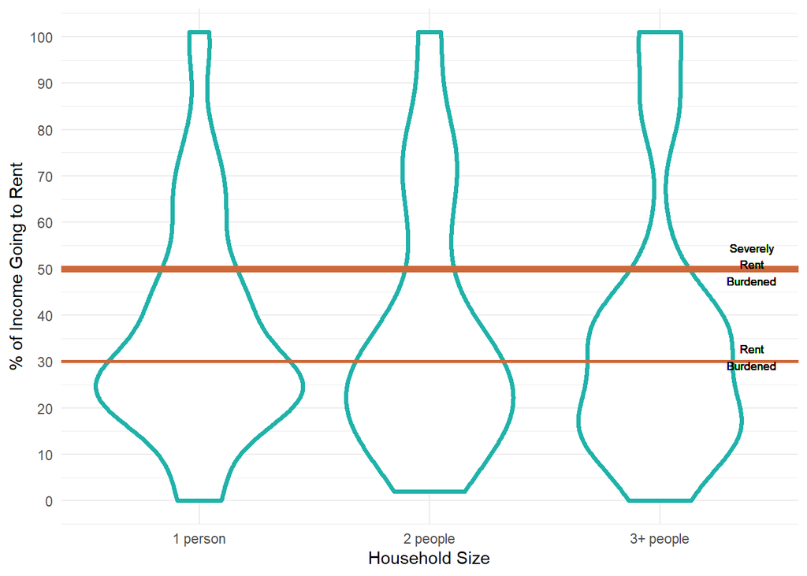

```r
ggplot(ass6_SEHeights_renters, aes(x =NP_simp, y = GRPIP)) +
  geom_violin(color="lightseagreen", size =1.4) +
  theme_minimal() +
  scale_x_discrete(name = "Household Size") +
  scale_y_continuous(name = "% of Income Going to Rent",
                     breaks = seq(0, 101, by = 10),
                     label = paste(prettyNum(seq(0, 101, by = 10))))  +
   geom_segment(
                y=30,
                yend=30,
                x=0,
                xend=100,
                alpha=.8,
                size=1,
                color ="sienna3") +

geom_segment(
                y=50,
                yend=50,
                x=0,
                xend=100,
                alpha=.8,
                size =2,
                color ="sienna3") +
  geom_text(aes(label=str_wrap("Rent Burdened",4),
                 y= 31,
                 x=3.4),
                 size=2.5,
                 color ="black") +

geom_text(aes(label=str_wrap("Severely Rent Burdened",4),
                 y= 51,
                 x=3.4),
                 size=2.5,
                 color ="black")
```

##### Downtown + Nob Hill + North Valley

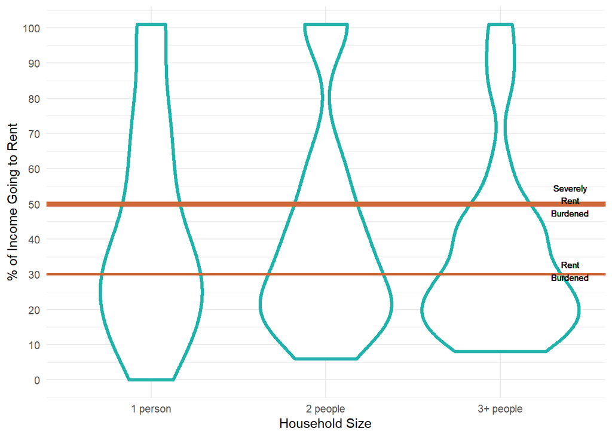

```r
ggplot(ass6_DT_NH_NV_renters, aes(x =NP_simp, y = GRPIP)) +
  geom_violin(color="lightseagreen", size =1.4) +
  theme_minimal() +
  scale_x_discrete(name = "Household Size") +
  scale_y_continuous(name = "% of Income Going to Rent",
                     breaks = seq(0, 101, by = 10),
                     label = paste(prettyNum(seq(0, 101, by = 10))))  +
   geom_segment(
                y=30,
                yend=30,
                x=0,
                xend=100,
                alpha=.8,
                size=1,
                color ="sienna3") +

geom_segment(
                y=50,
                yend=50,
                x=0,
                xend=100,
                alpha=.8,
                size =2,
                color ="sienna3") +
  geom_text(aes(label=str_wrap("Rent Burdened",4),
                 y= 31,
                 x=3.4),
                 size=2.5,
                 color ="black") +

geom_text(aes(label=str_wrap("Severely Rent Burdened",4),
                 y= 51,
                 x=3.4),
                 size=2.5,
                 color ="black")
```

## **Results: Part Two**

### ** Linear Regression Models**

In this analysis I am using a linear regression model to predict rent burden. The following are used as base cases. **Area:** Northeast Heights  
**Household Size:** 1 Person  
**Race & Ethnicity:** White (Non-Hispanic) (Chosen because non-hispanic whites are the largest share of population).  
**Rental Type**: Single Family Home  
**Education:** High School Diploma

```r
model_1 <- lm(GRPIP ~ PUMA_label + NP_simp + race_ethn + bld_type + when_built_simp + SCHL_simp, data =ass6_ABQs_renters)
summary(model_1)
```

```
##
## Call:
## lm(formula = GRPIP ~ PUMA_label + NP_simp + race_ethn + bld_type +
##     when_built_simp + SCHL_simp, data = ass6_ABQs_renters)
##
## Residuals:
##     Min      1Q  Median      3Q     Max
## -55.046 -18.361  -6.583  10.027  76.876
##
## Coefficients:
##                                         Estimate Std. Error t value Pr(>|t|)
## (Intercept)                              31.5889     3.5979   8.780  < 2e-16
## PUMA_labelDowntown, Nob Hill, N.Valley    5.7774     2.6231   2.203 0.027804
## PUMA_labelKirtland AFB/Gibson             8.6098     2.5668   3.354 0.000819
## PUMA_labelRio Rancho                      3.7185     2.8177   1.320 0.187171
## PUMA_labelSouth Valley                   13.3203     3.2474   4.102 4.35e-05
## PUMA_labelSoutheast Heights               2.8857     2.6286   1.098 0.272500
## NP_simp2 people                          -4.5344     2.1230  -2.136 0.032879
## NP_simp3+ people                         -7.7669     2.1880  -3.550 0.000399
## race_ethnAsian                            9.6588     4.7722   2.024 0.043177
## race_ethnHispanic (Non-White)             3.9465     2.9950   1.318 0.187842
## race_ethnHispanic (White))               -1.3065     1.9016  -0.687 0.492180
## race_ethnNative American                 -2.2922     2.5624  -0.895 0.371181
## race_ethnOther Race or Multiracial (NH)   3.6014     4.1159   0.875 0.381740
## bld_typeApartment                         3.7425     1.6895   2.215 0.026923
## bld_typeMobile Home/Trailer/5th Wheel    11.4353     3.6803   3.107 0.001930
## when_built_simpOlder                      6.0425     2.0410   2.961 0.003126
## SCHL_simpAssoc. Degree                   -0.7624     3.2198  -0.237 0.812853
## SCHL_simpBach Degree or Higher           -9.4588     2.0184  -4.686 3.08e-06
## SCHL_simpNo HS                            5.0619     2.1601   2.343 0.019261
## SCHL_simpSome HS, No Diploma              2.1348     2.7907   0.765 0.444412
##
## (Intercept)                             ***
## PUMA_labelDowntown, Nob Hill, N.Valley  *
## PUMA_labelKirtland AFB/Gibson           ***
## PUMA_labelRio Rancho
## PUMA_labelSouth Valley                  ***
## PUMA_labelSoutheast Heights
## NP_simp2 people                         *
## NP_simp3+ people                        ***
## race_ethnAsian                          *
## race_ethnHispanic (Non-White)
## race_ethnHispanic (White))
## race_ethnNative American
## race_ethnOther Race or Multiracial (NH)
## bld_typeApartment                       *
## bld_typeMobile Home/Trailer/5th Wheel   **
## when_built_simpOlder                    **
## SCHL_simpAssoc. Degree
## SCHL_simpBach Degree or Higher          ***
## SCHL_simpNo HS                          *
## SCHL_simpSome HS, No Diploma
## ---
## Signif. codes:  0 '***' 0.001 '**' 0.01 '*' 0.05 '.' 0.1 ' ' 1
##
## Residual standard error: 27 on 1303 degrees of freedom
##   (49 observations deleted due to missingness)
## Multiple R-squared:  0.078,  Adjusted R-squared:  0.06455
## F-statistic: 5.801 on 19 and 1303 DF,  p-value: 3.511e-14
```

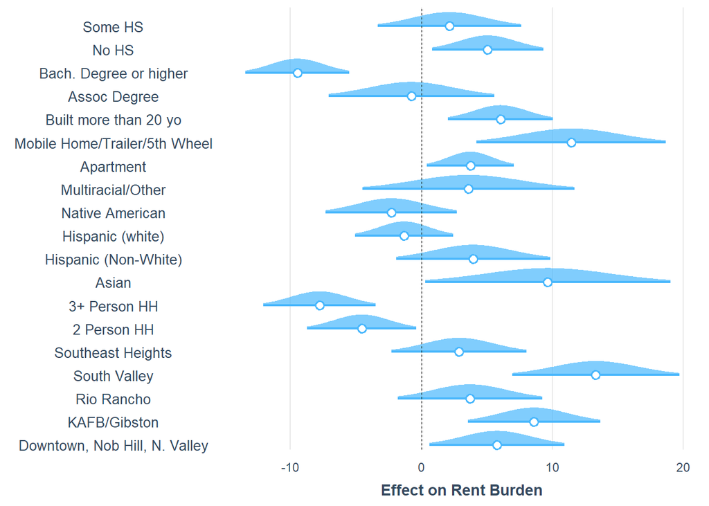

```r
coeff_interact <- c(

"Downtown, Nob Hill, N. Valley" = "PUMA_labelDowntown, Nob Hill, N.Valley",
"KAFB/Gibston" = "PUMA_labelKirtland AFB/Gibson",
"Rio Rancho" = "PUMA_labelRio Rancho",
"South Valley" = "PUMA_labelSouth Valley",
"Southeast Heights" ="PUMA_labelSoutheast Heights",
"2 Person HH" = "NP_simp2 people",
"3+ Person HH" = "NP_simp3+ people",
"Asian" = "race_ethnAsian",
"Hispanic (Non-White)" = "race_ethnHispanic (Non-White)",
"Hispanic (white)" = "race_ethnHispanic (White))",
"Native American" = "race_ethnNative American",
"Multiracial/Other" = "race_ethnOther Race or Multiracial (NH)",
"Apartment" = "bld_typeApartment",
"Mobile Home/Trailer/5th Wheel" = "bld_typeMobile Home/Trailer/5th Wheel",
"Built more than 20 yo" = "when_built_simpOlder",
"Assoc Degree" = "SCHL_simpAssoc. Degree",
"Bach. Degree or higher" = "SCHL_simpBach Degree or Higher",
"High School Dip." = "SCHL_simpHS Diploma",
"No HS" = "SCHL_simpNo HS",
"Some HS" = "SCHL_simpSome HS, No Diploma")


plot_coefs(model_1,
           coefs = coeff_interact,
           plot.distributions = TRUE,
           rescale.distributions = TRUE) +
  scale_x_continuous(name = "Effect on Rent Burden")
```

#### **Model 2 –> Interaction Terms**

```r
model_2_abq <- lm(GRPIP ~ PUMA_label + NP_simp  + race_ethn + bld_type + when_built_simp + SCHL_simp + PUMA_label:NP_simp + bld_type:NP_simp + race_ethn:NP_simp + SCHL_simp:NP_simp, data =ass6_ABQs_renters)
summary(model_2_abq)
```

```
##
## Call:
## lm(formula = GRPIP ~ PUMA_label + NP_simp + race_ethn + bld_type +
##     when_built_simp + SCHL_simp + PUMA_label:NP_simp + bld_type:NP_simp +
##     race_ethn:NP_simp + SCHL_simp:NP_simp, data = ass6_ABQs_renters)
##
## Residuals:
##     Min      1Q  Median      3Q     Max
## -58.397 -17.541  -4.889  10.784  76.866
##
## Coefficients:
##                                                           Estimate Std. Error
## (Intercept)                                               46.10894    6.15687
## PUMA_labelDowntown, Nob Hill, N.Valley                     4.20511    4.77989
## PUMA_labelKirtland AFB/Gibson                              4.06327    4.95494
## PUMA_labelRio Rancho                                      11.34902    5.95612
## PUMA_labelSouth Valley                                    15.02877    7.93308
## PUMA_labelSoutheast Heights                               -4.91792    4.93093
## NP_simp2 people                                          -17.91329    7.16820
## NP_simp3+ people                                         -28.56881    7.25979
## race_ethnAsian                                            -0.03308   10.25365
## race_ethnHispanic (Non-White)                             -7.81017    6.70140
## race_ethnHispanic (White))                               -10.31321    3.82151
## race_ethnNative American                                  -5.51768    5.70160
## race_ethnOther Race or Multiracial (NH)                    5.45135    8.30231
## bld_typeApartment                                         -0.67425    3.90363
## bld_typeMobile Home/Trailer/5th Wheel                    -17.82566   11.57440
## when_built_simpOlder                                       5.48460    2.04102
## SCHL_simpAssoc. Degree                                    -3.57791    5.56932
## SCHL_simpBach Degree or Higher                           -17.78895    3.46585
## SCHL_simpNo HS                                           -21.48262    7.26581
## SCHL_simpSome HS, No Diploma                              13.73776    7.58408
## PUMA_labelDowntown, Nob Hill, N.Valley:NP_simp2 people     5.85520    6.58888
## PUMA_labelKirtland AFB/Gibson:NP_simp2 people              3.32602    6.55572
## PUMA_labelRio Rancho:NP_simp2 people                     -16.93312    7.59217
## PUMA_labelSouth Valley:NP_simp2 people                    -5.98243   11.40221
## PUMA_labelSoutheast Heights:NP_simp2 people                8.85071    6.77874
## PUMA_labelDowntown, Nob Hill, N.Valley:NP_simp3+ people    0.55821    6.56226
## PUMA_labelKirtland AFB/Gibson:NP_simp3+ people             8.85184    6.53958
## PUMA_labelRio Rancho:NP_simp3+ people                     -3.56576    7.42527
```

[output cut: 69 more lines]

```
## NP_simp2 people:SCHL_simpAssoc. Degree                     1.011 0.312175
## NP_simp3+ people:SCHL_simpAssoc. Degree                   -0.150 0.880908
## NP_simp2 people:SCHL_simpBach Degree or Higher             1.746 0.081074 .
## NP_simp3+ people:SCHL_simpBach Degree or Higher            2.653 0.008071 **
## NP_simp2 people:SCHL_simpNo HS                             3.497 0.000486 ***
## NP_simp3+ people:SCHL_simpNo HS                            3.631 0.000293 ***
## NP_simp2 people:SCHL_simpSome HS, No Diploma              -0.700 0.484236
## NP_simp3+ people:SCHL_simpSome HS, No Diploma             -1.754 0.079653 .
## ---
## Signif. codes:  0 '***' 0.001 '**' 0.01 '*' 0.05 '.' 0.1 ' ' 1
##
## Residual standard error: 26.52 on 1271 degrees of freedom
##   (49 observations deleted due to missingness)
## Multiple R-squared:  0.1327, Adjusted R-squared:  0.0979
## F-statistic: 3.813 on 51 and 1271 DF,  p-value: < 2.2e-16
```

### **Variations of Interaction Model**

**The following three models are variations on the same interaction model**

#### *Holding Everything But Education Constant*

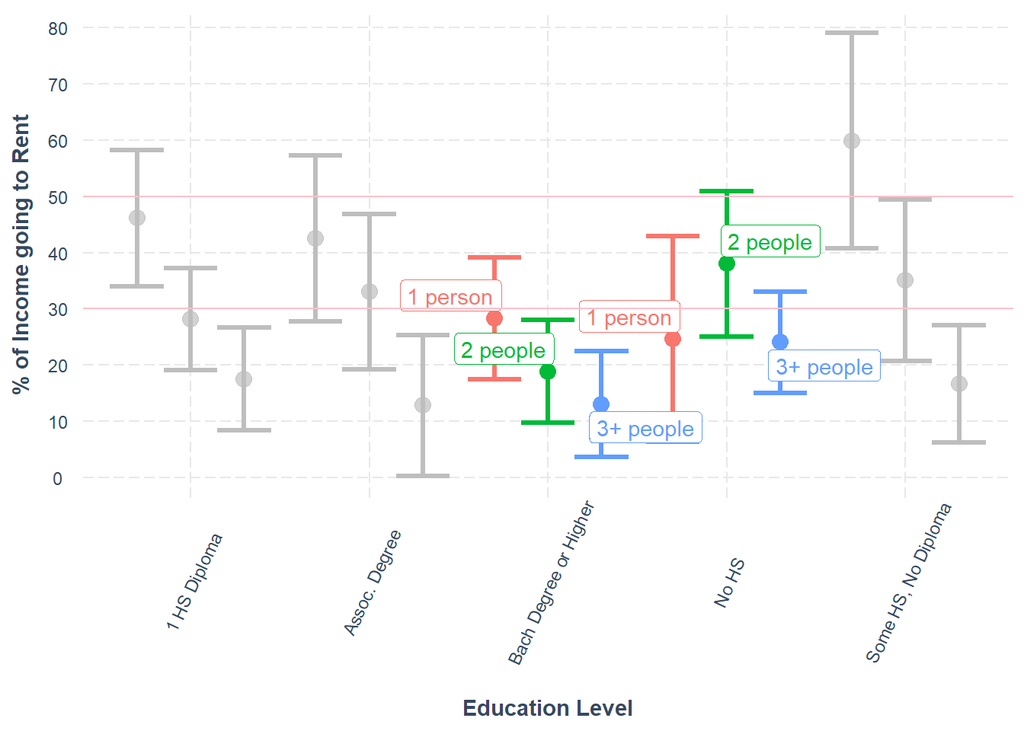

```r
cat_plot(model_2_abq, pred = SCHL_simp, modx = NP_simp, interval = TRUE) +
 scale_x_discrete(name = "Education Level") +
  scale_y_continuous(name = "% of Income going to Rent",
                     breaks = seq(0, 105, by = 10)) +
  theme(axis.text.x = element_text(angle=65, vjust=0.6)) +
  gghighlight(SCHL_simp =="No HS" | SCHL_simp == "Bach Degree or Higher")+
  scale_color_discrete(name = "") +
  scale_linetype_discrete(name = "") +
  scale_fill_discrete(name = "") +
   geom_segment(name="Rent Burden",
                y=30,
                yend=30,
                x=0,
                xend=100,
                alpha=.8,
                color ="pink") +

geom_segment(name="Rent Burden",
                y=50,
                yend=50,
                x=0,
                xend=100,
                alpha=.8,
                color ="pink")
```

#### Holding Everything but Neighborhood Constant

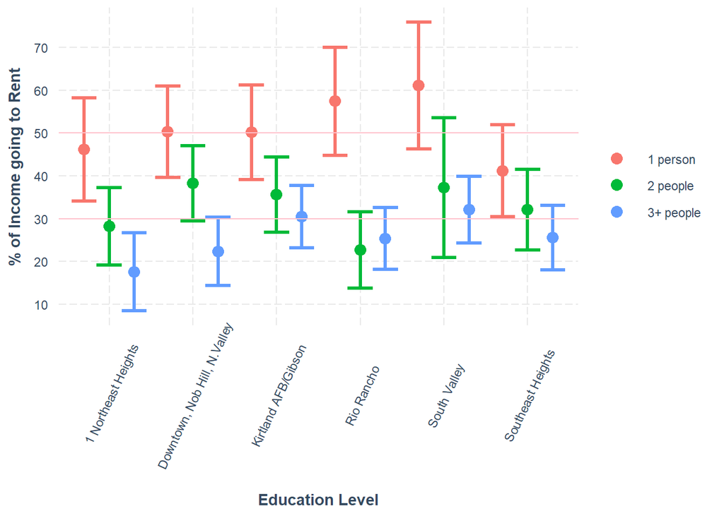

```r
cat_plot(model_2_abq, pred = PUMA_label, modx = NP_simp, interval = TRUE) +
 scale_x_discrete(name = "Education Level") +
  scale_y_continuous(name = "% of Income going to Rent",
                     breaks = seq(0, 105, by = 10)) +
  theme(axis.text.x = element_text(angle=65, vjust=0.6)) +
  scale_color_discrete(name = "") +
  scale_linetype_discrete(name = "") +
  scale_fill_discrete(name = "") +
   geom_segment(name="Rent Burden",
                y=30,
                yend=30,
                x=0,
                xend=100,
                alpha=.8,
                color ="pink") +

geom_segment(name="Rent Burden",
                y=50,
                yend=50,
                x=0,
                xend=100,
                alpha=.8,
                color ="pink")
```

#### *Holding Everything But Rental Type Constant*

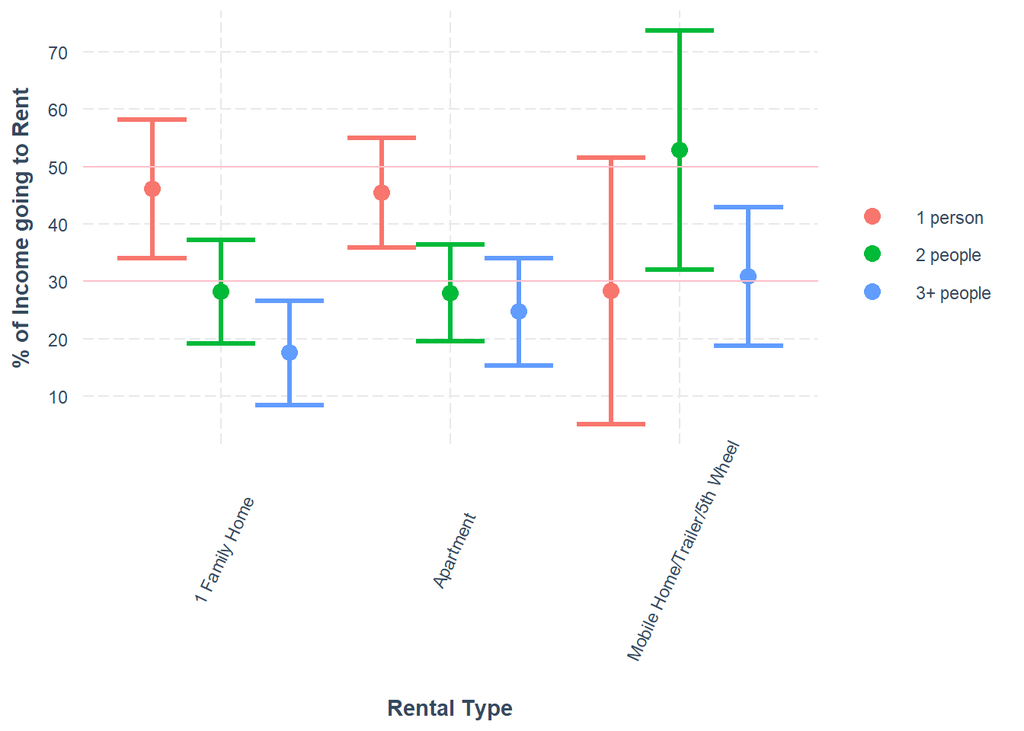

```r
cat_plot(model_2_abq, pred = bld_type, modx = NP_simp, interval = TRUE) +
 scale_x_discrete(name = "Rental Type") +
  scale_y_continuous(name = "% of Income going to Rent",
                     breaks = seq(0, 105, by = 10)) +
  theme(axis.text.x = element_text(angle=65, vjust=0.6)) +
  scale_color_discrete(name = "") +
  scale_linetype_discrete(name = "") +
  scale_fill_discrete(name = "") +
   geom_segment(name="Rent Burden",
                y=30,
                yend=30,
                x=0,
                xend=100,
                alpha=.8,
                color ="pink") +

geom_segment(name="Rent Burden",
                y=50,
                yend=50,
                x=0,
                xend=100,
                alpha=.8,
                color ="pink")
```

## **Results: Part 3**

The following models take the baseline model and show for some of the neighborhood. Given the small sample sizes, I decided to stick with baseline over showing the interaction plots for the individual scales.

### **South Valley**

#### South Valley Baseline Model

```r
model_SV_b <- lm(GRPIP ~  NP_simp + race_ethn + bld_type + when_built_simp + SCHL_simp, data =ass6_SVALLEY_renters)
summary(model_SV_b)
```

[output not shown]

```r
coeff_interact_NHoods <- c(


"2 Person HH" = "NP_simp2 people",
"3+ Person HH" = "NP_simp3+ people",
"Asian" = "race_ethnAsian",
"Hispanic (Non-White)" = "race_ethnHispanic (Non-White)",
"Hispanic (white)" = "race_ethnHispanic (White))",
"Native American" = "race_ethnNative American",
"Multiracial/Other" = "race_ethnOther Race or Multiracial (NH)",
"Apartment" = "bld_typeApartment",
"Mobile Home/Trailer/5th Wheel" = "bld_typeMobile Home/Trailer/5th Wheel",
"Built more than 20 yo" = "when_built_simpOlder",
"Assoc Degree" = "SCHL_simpAssoc. Degree",
"Bach. Degree or higher" = "SCHL_simpBach Degree or Higher",
"High School Dip." = "SCHL_simpHS Diploma",
"No HS" = "SCHL_simpNo HS",
"Some HS" = "SCHL_simpSome HS, No Diploma")


plot_coefs(model_SV_b,
           coefs = coeff_interact_NHoods,
           plot.distributions = TRUE,
           rescale.distributions = TRUE) +
  scale_x_continuous(name = "Effect on Rent Burden")
```

[output not shown]

### **Rio Rancho**

#### Rio Rancho Baseline Model

```r
model_RioR_b <- lm(GRPIP ~  NP_simp + race_ethn + bld_type + when_built_simp + SCHL_simp, data =ass6_RIO_R_renters)
summary(model_RioR_b)
```

[output not shown]

```r
coeff_interact_NHoods <- c(


"2 Person HH" = "NP_simp2 people",
"3+ Person HH" = "NP_simp3+ people",
"Asian" = "race_ethnAsian",
"Hispanic (Non-White)" = "race_ethnHispanic (Non-White)",
"Hispanic (white)" = "race_ethnHispanic (White))",
"Native American" = "race_ethnNative American",
"Multiracial/Other" = "race_ethnOther Race or Multiracial (NH)",
"Apartment" = "bld_typeApartment",
"Mobile Home/Trailer/5th Wheel" = "bld_typeMobile Home/Trailer/5th Wheel",
"Built more than 20 yo" = "when_built_simpOlder",
"Assoc Degree" = "SCHL_simpAssoc. Degree",
"Bach. Degree or higher" = "SCHL_simpBach Degree or Higher",
"High School Dip." = "SCHL_simpHS Diploma",
"No HS" = "SCHL_simpNo HS",
"Some HS" = "SCHL_simpSome HS, No Diploma")


plot_coefs(model_RioR_b,
           coefs = coeff_interact_NHoods,
           plot.distributions = TRUE,
           rescale.distributions = TRUE) +
  scale_x_continuous(name = "Effect on Rent Burden")
```

[output not shown]

#### Rio Rancho Baseline Model

```r
model_SEH_b <- lm(GRPIP ~  NP_simp + race_ethn + bld_type + when_built_simp + SCHL_simp, data =ass6_RIO_R_renters)
summary(model_SEH_b)
```

[output not shown]

```r
coeff_interact_NHoods <- c(


"2 Person HH" = "NP_simp2 people",
"3+ Person HH" = "NP_simp3+ people",
"Asian" = "race_ethnAsian",
"Hispanic (Non-White)" = "race_ethnHispanic (Non-White)",
"Hispanic (white)" = "race_ethnHispanic (White))",
"Native American" = "race_ethnNative American",
"Multiracial/Other" = "race_ethnOther Race or Multiracial (NH)",
"Apartment" = "bld_typeApartment",
"Mobile Home/Trailer/5th Wheel" = "bld_typeMobile Home/Trailer/5th Wheel",
"Built more than 20 yo" = "when_built_simpOlder",
"Assoc Degree" = "SCHL_simpAssoc. Degree",
"Bach. Degree or higher" = "SCHL_simpBach Degree or Higher",
"High School Dip." = "SCHL_simpHS Diploma",
"No HS" = "SCHL_simpNo HS",
"Some HS" = "SCHL_simpSome HS, No Diploma")


plot_coefs(model_SEH_b,
           coefs = coeff_interact_NHoods,
           plot.distributions = TRUE,
           rescale.distributions = TRUE) +
  scale_x_continuous(name = "Effect on Rent Burden")
```

[output not shown]

### **Downtown/ Nob Hill/ North Valley**

#### Baseline Model

```r
model_DT <- lm(GRPIP ~  NP_simp + race_ethn + bld_type + when_built_simp + SCHL_simp, data =ass6_DT_NH_NV_renters)
summary(model_DT)
```

[output not shown]

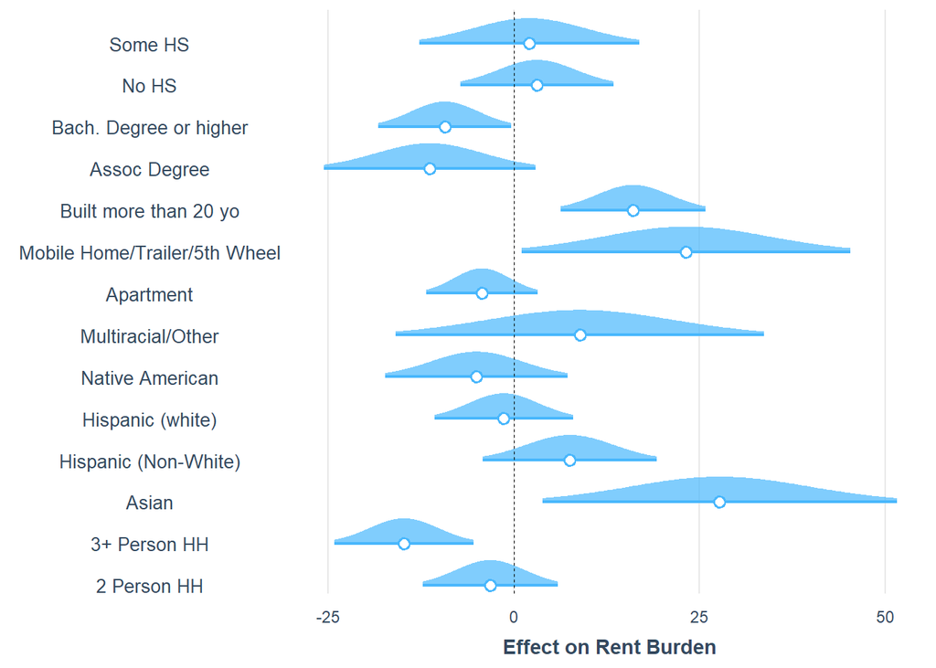

```r
coeff_interact_NHoods <- c(


"2 Person HH" = "NP_simp2 people",
"3+ Person HH" = "NP_simp3+ people",
"Asian" = "race_ethnAsian",
"Hispanic (Non-White)" = "race_ethnHispanic (Non-White)",
"Hispanic (white)" = "race_ethnHispanic (White))",
"Native American" = "race_ethnNative American",
"Multiracial/Other" = "race_ethnOther Race or Multiracial (NH)",
"Apartment" = "bld_typeApartment",
"Mobile Home/Trailer/5th Wheel" = "bld_typeMobile Home/Trailer/5th Wheel",
"Built more than 20 yo" = "when_built_simpOlder",
"Assoc Degree" = "SCHL_simpAssoc. Degree",
"Bach. Degree or higher" = "SCHL_simpBach Degree or Higher",
"High School Dip." = "SCHL_simpHS Diploma",
"No HS" = "SCHL_simpNo HS",
"Some HS" = "SCHL_simpSome HS, No Diploma")


plot_coefs(model_DT,
           coefs = coeff_interact_NHoods,
           plot.distributions = TRUE,
           rescale.distributions = TRUE) +
  scale_x_continuous(name = "Effect on Rent Burden")
```

## **Discussion**

To recap, my hypothesis before starting this analysis was that there are stat sig relationships between Rent Burden and variables such as education, neighborhood and race & ethnicity. The data shows that there are indeed some relationships within these groups, but not every category is stat significant. For example, while having dropped out of school by 9th grade or having a BA or higher has a stat sig impact for percent of rent going to income, within some of the other categories (such as having an associates degree) there are less obvious relationships.

A challenge of this analysis is the small sample size of observations, especially when broken down to renters per neighborhood. It is quite plausible that with a large dataset, we would see stat sig relationships that are currently not demonstrable.

## **Where do we go next**

In 2018 when Albuquerque was working on reforming their zoning code, there was ruckus at 1 Civic Plaza. While Tim Keller and the planning department were proposing certain changes that would work towards creating more affordable housing in the city–such as expanding where accessory dwelling units were to be allowed or construction of new affordable units–there were quite a few who were not happy with these proposals. This is to be expected, in the United States (and yes we are still in the US), virtually no change to the built environment is proposed without public pushback in this current moment, especially if that change has to do with affordable housing. To advocate for affordable housing in the city then, it is imperative that housing advocates and the general public are equipped with in-depth knowledge of what the city looks like for renters and low-income households. If our city is to thrive and provide for all Burqueños, we must know what the existing conditions and relationships are. We cannot rely on the assumption that albuquerque has inexpensive housing that is in reach of all. Sure we might have inexpensive housing compared to Arizona, but that still doesn’t mean its affordable.

What I hope this analysis shows is that while some of what we expect to be true based on our everyday experience of the city is true, some of it is not. And more importantly, there are things we as Burqueños do not already know. Looking at what Albuquerque can do in making affordable units available to single renters may be an unexpected way to work towards the city we all want.